# Practical Machine Learning Assignment

Rohit Jain

11/23/2018

## Background:

Using devices such as Jawbone Up, Nike FuelBand, and Fitbit it is now possible to collect a large amount of data about personal activity relatively inexpensively. These type of devices are part of the quantified self movement – a group of enthusiasts who take measurements about themselves regularly to improve their health, to find patterns in their behavior, or because they are tech geeks. One thing that people regularly do is quantify how much of a particular activity they do, but they rarely quantify how well they do it. In this project, your goal will be to use data from accelerometers on the belt, forearm, arm, and dumbell of 6 participants. They were asked to perform barbell lifts correctly and incorrectly in 5 different ways. More information is available from the website here: http://web.archive.org/web/20161224072740/http:/groupware.les.inf.puc-rio.br/har (see the section on the Weight Lifting Exercise Dataset).

## Data

The training data for this project are available here:

https://d396qusza40orc.cloudfront.net/predmachlearn/pml-training.csv

The test data are available here:

https://d396qusza40orc.cloudfront.net/predmachlearn/pml-testing.csv

The data for this project come from this source: http://groupware.les.inf.puc-rio.br/har.

## Objective

The goal of this project is to predict the class of exercise using different Machine learning Algos.

## Modeling:

#### Setting up the environment:

```r
library(dplyr)
library(caret)
library(rpart)
library(rpart.plot)
library(randomForest)
library(e1071)
library(corrplot)
library(kableExtra)
```

#### Data Preprocessing(Loading/Partioning/Cleaning):

```r
set.seed(34213)
## Data loading
trainDt <- read.csv("pml-training.csv")
testDt <- read.csv("pml-testing.csv")
dim(trainDt)
```

```
## [1] 19622   160
```

```r
dim(testDt)
```

```
## [1]  20 160
```

```r
#str(trainDt)
## removing the first cloumns of the data set as they are not significate for the modeling
trainDt <- select(trainDt, -c(1:5))
testDt <- select(testDt, -c(1:5))

## Data Partitioning
inTrainSub <- createDataPartition(y = trainDt$classe, p = 0.7, list = FALSE)
subTrain <- trainDt[inTrainSub,]
subTest <- trainDt[-inTrainSub,]

# Data Cleaning
NZV <- nearZeroVar(subTrain)
TrainSet <- subTrain[, -NZV]
TestSet  <- subTest[, -NZV]
Test <- testDt[,-NZV]
AllNA    <- sapply(TrainSet, function(x) mean(is.na(x))) > 0.95
TrainSet <- TrainSet[, AllNA==FALSE]
TestSet <- TestSet[, AllNA==FALSE]
Test <- testDt[,AllNA ==FALSE]

# dimension of the data sets:
dim(TrainSet)
```

```
## [1] 13737    54
```

```r
dim(TestSet)
```

```
## [1] 5885   54
```

```r
dim(Test)
```

```
## [1] 20 81
```

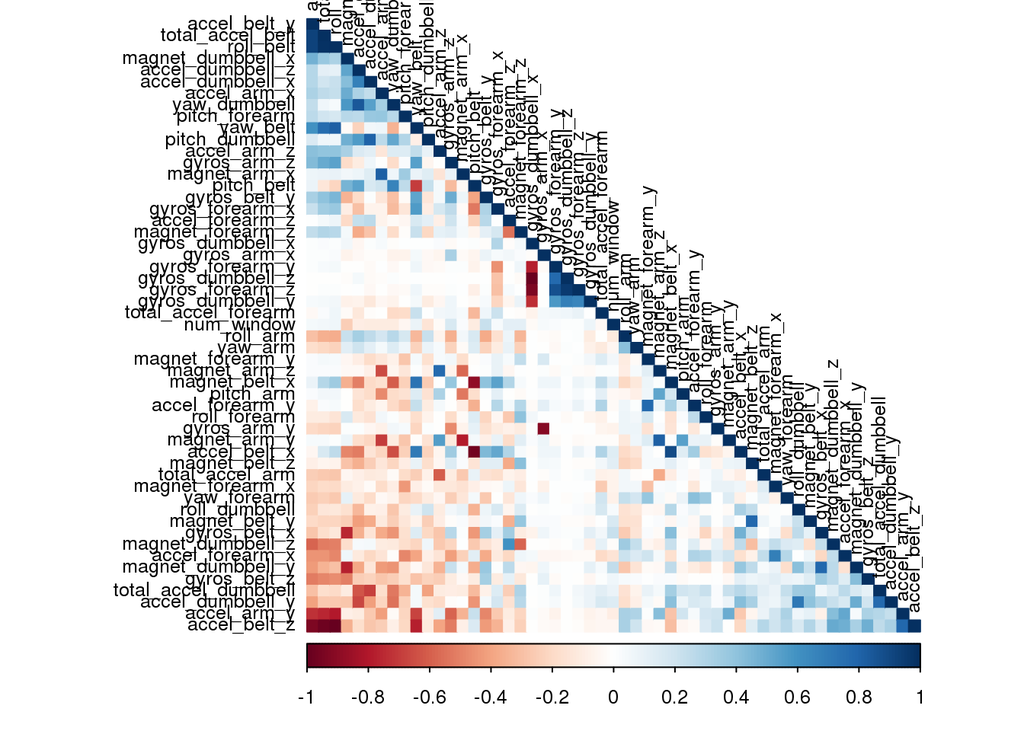

```r
corrplot(cor(TrainSet[,-ncol(TrainSet)]),
order = "FPC",
method = "color",
type = "lower",
tl.cex = 0.8,
tl.col = rgb(0, 0, 0)
)
```

#### Models:

#### 1. Decision Tree

```r
modelFit_dt <- rpart(classe ~ ., data=TrainSet, method="class")
pred_dt <- predict(modelFit_dt, TestSet, type = "class")
conMatDt <- confusionMatrix(pred_dt,TestSet$classe)
conMatDt
```

```
## Confusion Matrix and Statistics
##
##           Reference
## Prediction    A    B    C    D    E
##          A 1431  152   35   36    9
##          B   98  803  121   75   55
##          C   40   54  842  128   43
##          D   70   98   25  609   65
##          E   35   32    3  116  910
##
## Overall Statistics
##
##                Accuracy : 0.7808
##                  95% CI : (0.77, 0.7913)
##     No Information Rate : 0.2845
##     P-Value [Acc > NIR] : < 2.2e-16
##
##                   Kappa : 0.7227
##  Mcnemar's Test P-Value : < 2.2e-16
##
## Statistics by Class:
##
##                      Class: A Class: B Class: C Class: D Class: E
## Sensitivity            0.8548   0.7050   0.8207   0.6317   0.8410
## Specificity            0.9449   0.9265   0.9455   0.9476   0.9613
## Pos Pred Value         0.8605   0.6970   0.7606   0.7024   0.8303
## Neg Pred Value         0.9424   0.9290   0.9615   0.9293   0.9641
## Prevalence             0.2845   0.1935   0.1743   0.1638   0.1839
## Detection Rate         0.2432   0.1364   0.1431   0.1035   0.1546
## Detection Prevalence   0.2826   0.1958   0.1881   0.1473   0.1862
## Balanced Accuracy      0.8999   0.8157   0.8831   0.7897   0.9012
```

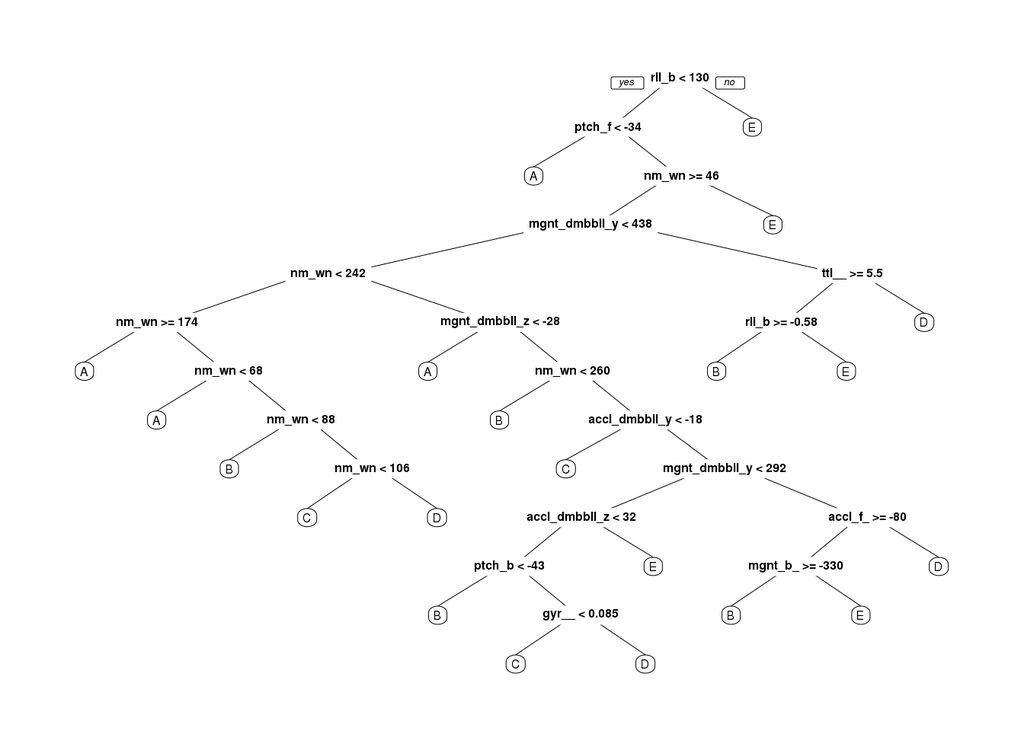

```r
prp(modelFit_dt,varlen = 5, cex = 0.5)
```

#### 2. Support Vector Machine

```r
modelFit_svm <- svm(classe ~ ., data = TrainSet)
pred_svm <- predict(modelFit_svm,TestSet)
confMatSVM <- confusionMatrix(pred_svm, TestSet$classe)
confMatSVM
```

```
## Confusion Matrix and Statistics
##
##           Reference
## Prediction    A    B    C    D    E
##          A 1637   69    4    0    0
##          B    9 1048   35    1    1
##          C   23   20  978   86   11
##          D    1    1    9  876   26
##          E    4    1    0    1 1044
##
## Overall Statistics
##
##                Accuracy : 0.9487
##                  95% CI : (0.9427, 0.9542)
##     No Information Rate : 0.2845
##     P-Value [Acc > NIR] : < 2.2e-16
##
##                   Kappa : 0.935
##  Mcnemar's Test P-Value : < 2.2e-16
##
## Statistics by Class:
##
##                      Class: A Class: B Class: C Class: D Class: E
## Sensitivity            0.9779   0.9201   0.9532   0.9087   0.9649
## Specificity            0.9827   0.9903   0.9712   0.9925   0.9988
## Pos Pred Value         0.9573   0.9580   0.8748   0.9595   0.9943
## Neg Pred Value         0.9911   0.9810   0.9899   0.9823   0.9921
## Prevalence             0.2845   0.1935   0.1743   0.1638   0.1839
## Detection Rate         0.2782   0.1781   0.1662   0.1489   0.1774
## Detection Prevalence   0.2906   0.1859   0.1900   0.1551   0.1784
## Balanced Accuracy      0.9803   0.9552   0.9622   0.9506   0.9818
```

#### 3. Random Forest

```r
controlRF <- trainControl(method="cv", number=3, verboseIter=FALSE)
modelFit_rf <- train(
                      classe ~ .,
                      data = TrainSet,
                      method = "rf",
                      trControl = controlRF
                    )
modelFit_rf$finalModel
```

```
##
## Call:
##  randomForest(x = x, y = y, mtry = param$mtry)
##                Type of random forest: classification
##                      Number of trees: 500
## No. of variables tried at each split: 27
##
##         OOB estimate of  error rate: 0.18%
## Confusion matrix:
##      A    B    C    D    E  class.error
## A 3905    0    0    0    1 0.0002560164
## B    8 2649    1    0    0 0.0033860045
## C    0    5 2390    1    0 0.0025041736
## D    0    0    5 2247    0 0.0022202487
## E    0    0    0    4 2521 0.0015841584
```

```r
pred_rf <- predict(modelFit_rf, TestSet)
confMatRandForest <- confusionMatrix(pred_rf, TestSet$classe)
confMatRandForest
```

```
## Confusion Matrix and Statistics
##
##           Reference
## Prediction    A    B    C    D    E
##          A 1673    3    0    0    0
##          B    1 1136    5    0    0
##          C    0    0 1021    3    0
##          D    0    0    0  960    1
##          E    0    0    0    1 1081
##
## Overall Statistics
##
##                Accuracy : 0.9976
##                  95% CI : (0.996, 0.9987)
##     No Information Rate : 0.2845
##     P-Value [Acc > NIR] : < 2.2e-16
##
##                   Kappa : 0.997
##  Mcnemar's Test P-Value : NA
##
## Statistics by Class:
##
##                      Class: A Class: B Class: C Class: D Class: E
## Sensitivity            0.9994   0.9974   0.9951   0.9959   0.9991
## Specificity            0.9993   0.9987   0.9994   0.9998   0.9998
## Pos Pred Value         0.9982   0.9947   0.9971   0.9990   0.9991
## Neg Pred Value         0.9998   0.9994   0.9990   0.9992   0.9998
## Prevalence             0.2845   0.1935   0.1743   0.1638   0.1839
## Detection Rate         0.2843   0.1930   0.1735   0.1631   0.1837
## Detection Prevalence   0.2848   0.1941   0.1740   0.1633   0.1839
## Balanced Accuracy      0.9993   0.9981   0.9973   0.9978   0.9994
```

#### Model Comparison

In this section we will be ploting the predicted Vs actual classe for the “TestSet”. And Compaire the accuracy of diffrent models we have fitted. The plots are given in increasing order of accuracy below:

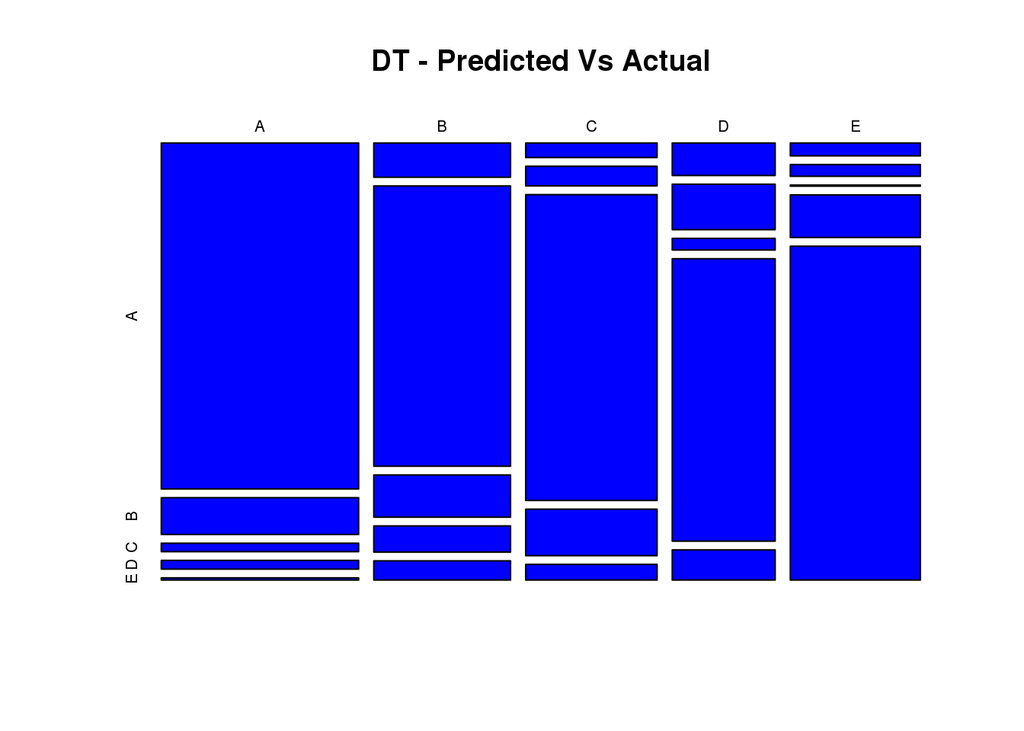

```r
tsvm <- table(pred_svm,TestSet$classe)
trf <- table(pred_rf,TestSet$classe)
tdt <- table(pred_dt, TestSet$classe)
plot(tdt, col = "blue", main = "DT - Predicted Vs Actual", xlab = "")
```

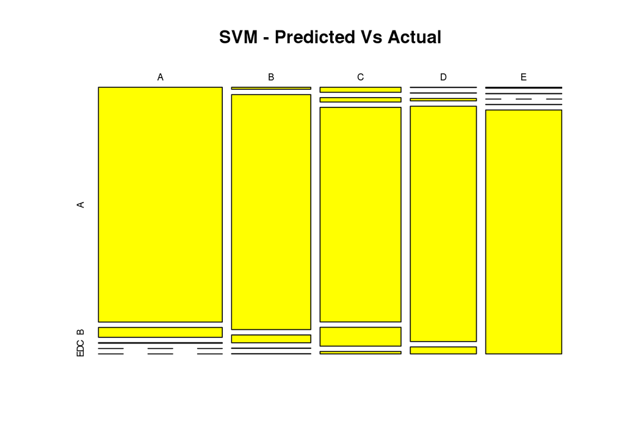

```r
plot(tsvm, col = "yellow", main = "SVM - Predicted Vs Actual", xlab = "")
```

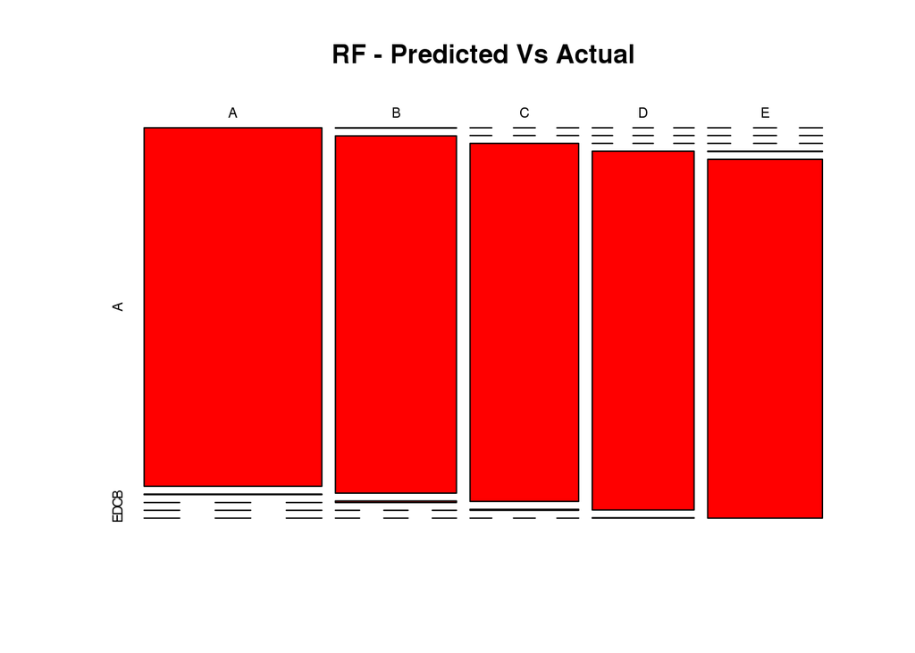

```r
plot(trf, col = "red", main = "RF - Predicted Vs Actual", xlab = "")
```

```r
Accuracy <- data.frame(
            Accuracy_RandomForest = paste0(round(confMatRandForest$overall["Accuracy"],4)*100 , "%"),
                  Accuracy_SVM = paste0(round(confMatSVM$overall["Accuracy"],4)*100,"%"),
                  Accuracy_DT = paste0(round(conMatDt$overall["Accuracy"],4)*100,"%")
                  )
kable(Accuracy)
```

| Accuracy_RandomForest | Accuracy_SVM | Accuracy_DT |
| --- | --- | --- |
| 99.76% | 94.87% | 78.08% |

## Conclusion:

On the basis of the comparison of models above **“Random Forest”** is the best suited model for the prediction.

Following is the predicted “classe” for the given test data.

```r
final_Prediction <- predict(modelFit_rf,testDt)
final_Prediction
```

```
##  [1] B A B A A E D B A A B C B A E E A B B B
## Levels: A B C D E
```